# Misinformation and Social Behaviour Lab Seminar Series Invited Talk - Bella Ren - Beyond Belief: Social Motive for Sharing Conspiracy Theories

2022-02-11T00:00:00Z

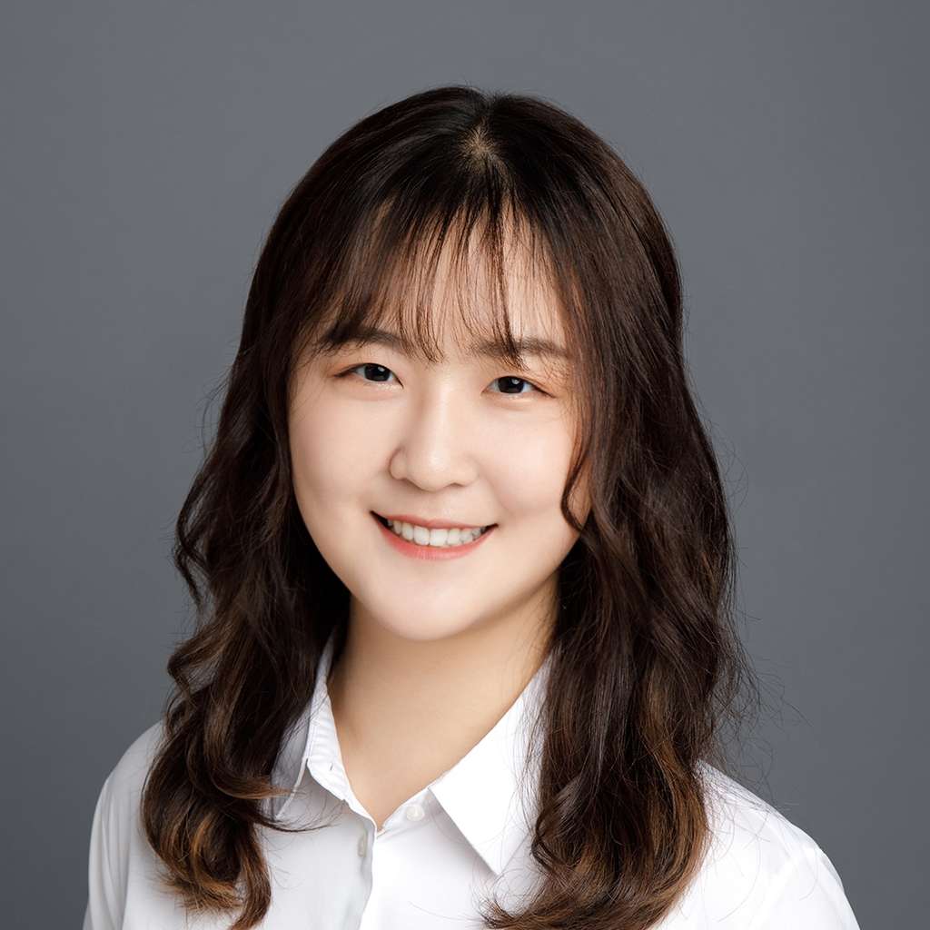

Bella Ren

Date: March 11th 2022

Time: 10am Melbourne local time

**This talk is open to lab members, students and researchers at Deakin University and members of the public. [Join Zoom Meeting](https://deakin.zoom.us/j/89601954126?pwd=MjQrOWFQNjBKNXZVeStINTdJRTFtUT09)**

*The spread of conspiracy theories has significantly hindered our ability to deal with crises related to the pandemic, climate science, and many other political and social issues. Therefore, it is crucial to understand why people share conspiracy theories. In a series of studies, we explore the social motives for sharing conspiracy theories. We propose that people knowingly share information that they know to be untrue to generate social engagement. Even though people know that factual news are more accurate than conspiracy theories, they expect sharing conspiracy theories to generate more social feedback (i.e. comments and “likes”) than sharing factual news. We then explore how the motivation to generate social engagement interacts with social environment to direct individuals’ content sharing decisions. In several interactive multi-round content-sharing studies, we find that people are very sensitive to the social feedback they receive in the social environment. Giving more positive social feedback for sharing conspiracy theories significantly increases people’s tendency to share these conspiracy theories that they do not believe in. Once formed, this behavioral tendency also becomes “sticky” and is hard to reverse. Our findings substantially develop our understanding of why and when individuals are most likely to share conspiracy theories. These findings also make important contributions to understanding and curbing the spread of misinformation.*